# Detecting characteristics shared by people who have longer trip duraction

## Dataset Overview

> This data set includes information about individual rides made in a bike-sharing system covering the greater San Francisco Bay area in February 2019, it has 183412 observations and various feature such as the duration, longitude, latitude. I dropped feature that are not needfull for this analysis.

## Visualization 1 : Duration distribution

> Due the outliers, duration distribution has been right skewed, i dropped outliers and applied log transform to duration attribute and i found an unimodel distribution with a peak around 500 seconds

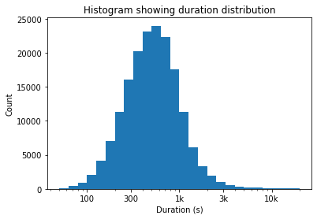

## Visualization 2: Distribution of start day of week

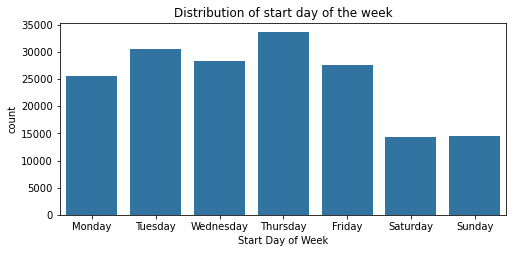

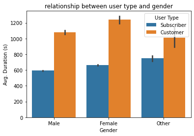

## Visualization 4: duration, start day of week, user type

> The plot shows that the customer has the highest duration and the other gender is riding more in the basis of start day of week. The customers have the rides with the highest duration

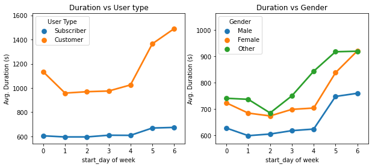

**Insights in the data**

- The other gender has the longer average ride duration
- The Customers have the longer average ride duration
- The female customers have the longer ride duration
- Sutardays and sundays have the longer ride duration

**Recommendations**

> It is recommended that Ford Gobike can attract customers to become subscribers